# Assignment 2 - Srujana Vanka, 2020102005

```
Box-Cox transformed 'season' (optimal lambda: 0.71)
```

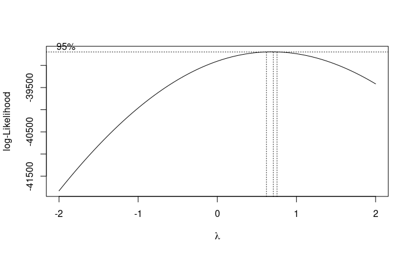

```
Box-Cox transformed 'holiday' (optimal lambda: -2.00)
```

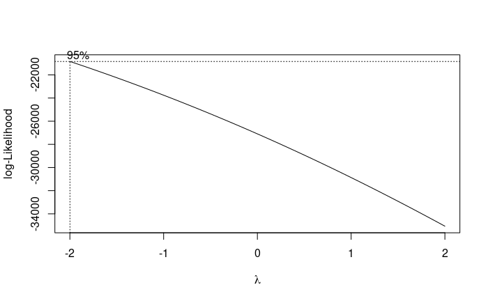

```
Box-Cox transformed 'workingday' (optimal lambda: 2.00)
```

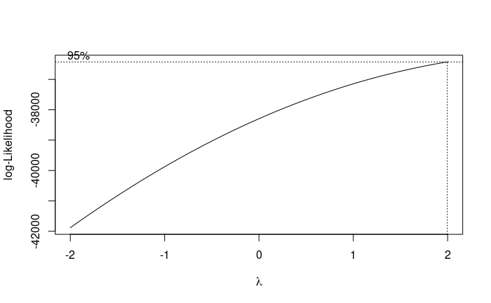

```
Box-Cox transformed 'weather' (optimal lambda: -2.00)
```

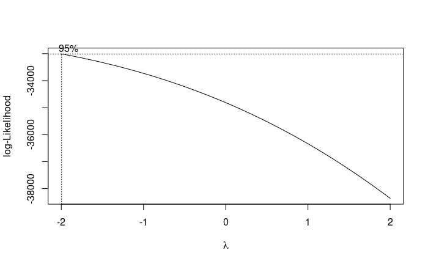

```
Box-Cox transformed 'temp' (optimal lambda: 0.83)
```

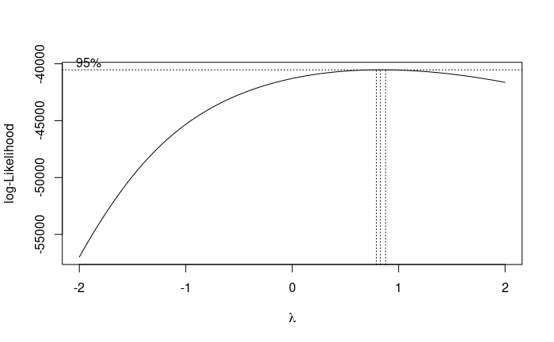

```
Box-Cox transformed 'atemp' (optimal lambda: 0.99)
```

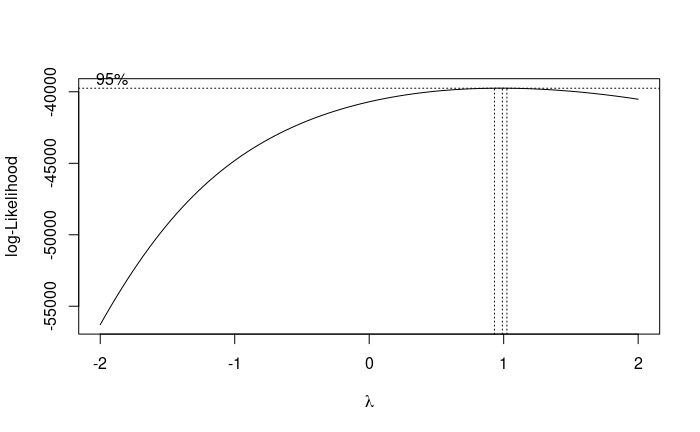

```
Box-Cox transformed 'humidity' (optimal lambda: 0.99)
```

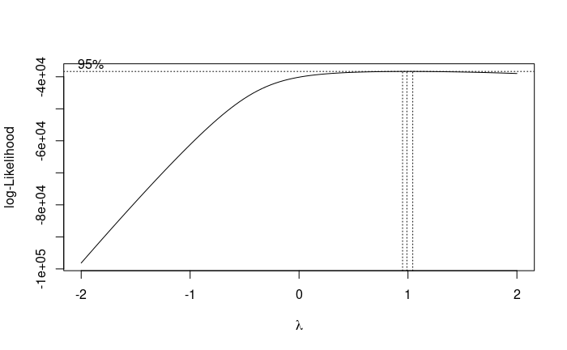

```
Box-Cox transformed 'windspeed' (optimal lambda: 0.67)
```

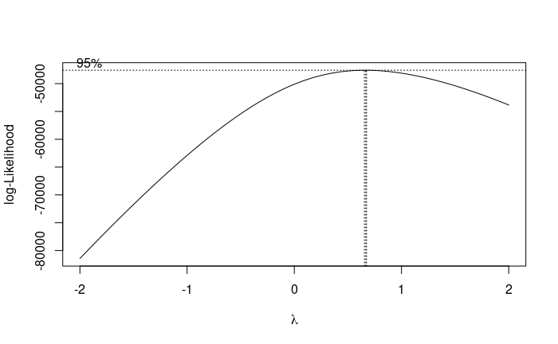

```
Box-Cox transformed 'casual' (optimal lambda: 0.06)
```

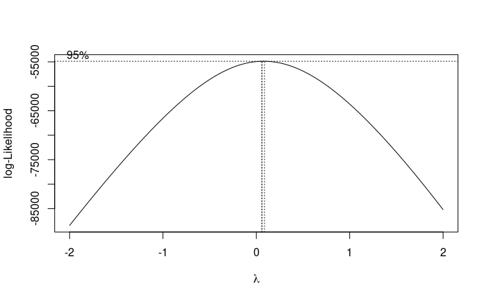

```
Box-Cox transformed 'registered' (optimal lambda: 0.30)
```

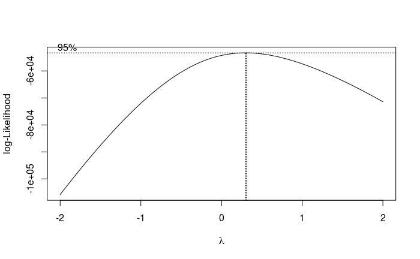

```
Box-Cox transformed 'count' (optimal lambda: 0.30)
```

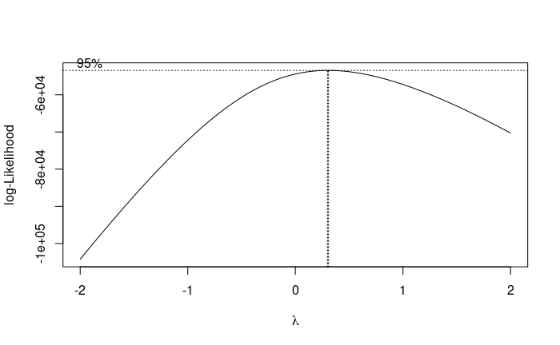

```r
library(MASS)
num_cols <- names(df)[sapply(df, is.numeric)]
# Apply Box-Cox to Non-Normal Variables
for (col in num_cols) {
  # Perform Shapiro-Wilk test for normality
  if (length(df[[col]]) > 5000) {
    sample_data <- sample(df[[col]], 5000)
  } else {
    sample_data <- df[[col]]
  }
  test_result <- shapiro.test(sample_data)
  if (test_result$p.value <= 0.05) {
    bc_transform <- boxcox(df[[col]] + 1 ~ 1, lambda = seq(-2, 2, 0.1))
    optimal_lambda <- bc_transform$x[which.max(bc_transform$y)]
    df[[col]] <- (df[[col]] + 1)^optimal_lambda - 1
    cat(sprintf("Box-Cox transformed '%s' (optimal lambda: %.2f)\n", col, optimal_lambda))
  }
}
```

#### Purpose of Box-Cox Transformation:

- The Box-Cox transformation is employed to reshape distributions that deviate from normality, making them more Gaussian in nature.
- The primary goal is to enhance the robustness of various statistical methods by ensuring that the data adheres more closely to normal distribution assumptions.

#### Role of Lambda (λ) Parameter:

- The λ parameter plays a crucial role in defining the nature of the transformation.
- A λ value around 1 suggests that minimal alteration is required for normalization.
- A λ close to 0 indicates that a logarithmic transformation provides an optimal approximation.
- λ values less than 0 signify the need for inverse transformations to achieve normality.

In summary, the Box-Cox transformation serves as a versatile tool for normalizing distributions, and the interpretation of lambda values provides insights into the degree of skewness and the effectiveness of the transformation for specific variables.

### 3. Explore partial or semi-partial correlations

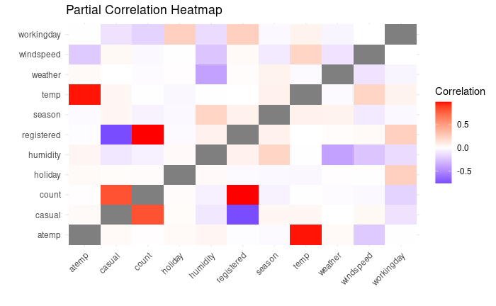

```r
library(ppcor)
library(reshape)
numeric_columns <- names(df)[sapply(df, is.numeric)]
partial_corrs <- matrix(NA, nrow = length(numeric_columns), ncol = length(numeric_columns))
rownames(partial_corrs) <- numeric_columns
colnames(partial_corrs) <- numeric_columns
# Loop over all pairs of variables
for (var1 in numeric_columns) {
  for (var2 in numeric_columns) {
    if (var1 != var2) {
      # Get the names of the control variables
      covars <- setdiff(numeric_columns, c(var1, var2))
      # Calculate the partial correlation
      partial_corr <- pcor.test(df[[var1]], df[[var2]], df[covars])
      # Store the partial correlation in the matrix
      partial_corrs[var1, var2] <- partial_corr$estimate
    }
  }
}
# Convert the matrix to a dataframe for plotting
partial_corrs_df <- melt(partial_corrs)
names(partial_corrs_df) <- c("Var1", "Var2", "Correlation")
# Plot the heatmap
ggplot(data = partial_corrs_df, aes(x = Var1, y = Var2, fill = Correlation))+geom_tile() +scale_fill_gradient2(low = "blue", high ="red", mid = "white", midpoint =0) +theme_minimal() +theme(axis.text.x = element_text(angle = 45, hjust = 1)) + labs(title = "Partial Correlation Heatmap", x = "", y = "")
```

#### High Positive Correlation:

- **atemp vs temp:**
  - The variables `atemp` (feels-like temperature) and `temp` (actual temperature) exhibit a high positive correlation. This suggests that as the actual temperature increases, the perceived or feels-like temperature also tends to increase.
- **count vs registered:**
  - There is a strong positive correlation between the total count of users (`count`) and the count of registered users (`registered`). This indicates that as the overall usage increases, the number of registered users also tends to increase.
- **count vs casual:**
  - The total count of users (`count`) shows a significant positive correlation with the count of casual users (`casual`). This implies that as the total usage increases, the number of casual users also tends to increase.

#### High Negative Correlation:

- **casual vs registered:**
  - There is a substantial negative correlation between the count of casual users (`casual`) and the count of registered users (`registered`). This suggests an inverse relationship, indicating that when the count of casual users increases, the count of registered users tends to decrease and vice versa.
- **humidity vs weather:**
  - The variables `humidity` and `weather` exhibit a notable negative correlation. This implies that as humidity increases, the weather condition tends to be less severe or extreme.

It’s important to note that these observations are made while controlling for all other variables (covariates) in the dataset. Partial correlation allows us to assess the relationship between two variables while taking into account the potential influence of other variables, providing a more refined understanding of their association.